# Selection: practical 2

Lewis Spurgin

## Introduction

In this practical we will look at two approaches for detecting *recent* selection among populations - one that requires discrete, predefined populations, and one that does not

## The data

We will be using the great tit data set from the population structure practical. You do not need to copy the file across, but you do need to copy the selection2 folder from the ubuntu Dati to your home directory, as follows:

```r
cd
cp -r Dati/selection2 .
cd selection2
```

In this session we are looking for loci under selection, so we do not want to filter based on Hardy-Weinberg, or to prune based on LD, as this would remove loads of interesting information. However, we still want to exclude related individuals. You can create such a file using the information you generated in the population structure practical folder using a single line of plink code. Write a new plink file to the selection folder. The file should contain only unrelated individuals, but all markers

```r
plink --bfile ../population_structure/GreatTits --keep ../population_structure/GreatTitsFilteredPruned.rel.id --make-bed --out GreatTitsUnrel
```

## Instructions

### Locus $F_{ST}$

We can calculate $F_{ST}$ very easily within plink - in fact we have already done this in the population structure practical, using a python script. But in that instance we were only interested in average $F_{ST}$ across pairs of populations. We are now interested in the $F_{ST}$ for each marker across all of our populations. Can you figure out how to calculate this?

```r
plink --bfile GreatTitsUnrel --family --fst --out GreatTitsUnrel
```

Check the plink help and make sure you are happy with what the “family” tag is doing. Regardless, is this the best way to define our populations? What did our Admixture results show? We will now try to use our Admixture results from the $K$ = 4 analysis to assign each individual to an “Admixture population”, then run a locus-based $F_{ST}$ analysis across the Admixture populations. If you think you can do this, go for it! Otherwise, step-by-step instructions below.

Remember that your “.Q” file from the Admixture analysis has one line per individual, with individuals in the same order as in your plink file. It then has the proportion of each cluster assigned to each individual as a separate column (so 4 columns for the $K$ - 4 analysis). What we need to do is detene, for each individual, which is the ‘largest’ of the four clusters. We can do this in R. Start up R in your server console, then load your admixture output into a data frame.

```r
R
library(tidyverse)
dd <- read_delim("../population_structure/admixture/GreatTitsThinned.4.Q",delim = " ", col_names = F)
```

Change the column names to “K1” to “K4”.

```r
colnames(dd) <- paste0("K",c(1:4))
```

We now wish to generate a vector that tells us, for each individual, which of K1 to K4 is largest. Can you figure out how to do this, either using a `for()` loop, or using `apply()`?

```r
#Using a for loop
output <- rep(NA,nrow(dd))
for(i in 1:nrow(dd))
{
  output[i] <- names(which.max(dd[i,]))
}

#Using apply - faster and neater
output <- apply(dd,1,function(x) names(which.max(x)))
```

Make sure that you fully understand how the above code has worked. Look up the help files for each function in the code, and discuss with your colleagues.

To define populations in plink, we are going to need to give it a file with our original population IDs in the first column, individual IDs in the second, and new population IDs in the third. We can create this using our output, and our.fam file. Load the .fam file into R

```r
pops <- read_delim("GreatTitsUnrel.fam", delim = " ",col_names = FALSE)
```

Now write an output file.

```r
towrite <- data.frame(oldpop = pops$X1,ind = pops$X2,newpop = output)
write_delim(towrite,"K4pops.txt",delim = "\t")
```

Now we can quit R, and use plink to calculate $F_{ST}$ based on our admixture proportions.

```r
plink --bfile GreatTitsUnrel --within K4pops.txt --fst --out GreatTitsK4
```

### EigenGWAS

Have a read of the EigenGWAS documentation here. This approach, along with a few other closely related approaches uses a GWAS on eigenvectors from a PCA to detect loci under divergent selection.

Navigate into the EigenGWAS folder. Now try to figure out how to run EigenGWAS on the first four eigenvectors from a PCA.

```r
java -jar gear.jar eigengwas --bfile ../GreatTitsUnrel --ev 4 --out GreatTitsUnrel
```

This analysis will take a little while to run - while it’s running, you can start downloading your other files - a list of what you need to download is below.

Given that EigenGWAS is a new program, it would be sensible to check the output files from the EigenGWAS carefully.

### Making plots

Copy the following files to a folder called session8_output:

- $F_{ST}$ between your geographic populations (first plink analysis, ending in .fst)
- $F_{ST}$ between your admixture populations (second plink analysis, ending in .fst)
- Your Eigenvectors from the EigenGWAS analysis (ending in .eigenvec)
- Your EigenGWAS results (four files, all ending in .egwas)

Now download this file to your laptop using scp or pscp.

We are going to do the plotting slightly differently this time. I will introduce you to some of the plots and functions you can run, then it is up to you to make a publication quality figure from our selection analyses.

Let’s first explore our $F_{ST}$ analyses.

```r
library(tidyverse)
library(cowplot) #for later
pop_fst <- read_delim("GreatTitsUnrel.fst", delim = "\t")
pop_fst
```

```
## # A tibble: 343,705 x 5
##      CHR SNP            POS NMISS       FST
##    <dbl> <chr>        <dbl> <dbl>     <dbl>
##  1     1 AX-100678681   511   212  0.0591
##  2     1 AX-100747228  5379   213 -0.00299
##  3     1 AX-100836047 21413   213  0.0278
##  4     1 AX-100918667 23383   213  0.00269
##  5     1 AX-100974310 26112   213 -0.00516
##  6     1 AX-100811471 28471   213  0.000778
##  7     1 AX-100414284 35125   212 -0.00255
##  8     1 AX-100837466 46003   213  0.00660
##  9     1 AX-100786950 46904   211  0.0805
## 10     1 AX-100015822 58982   209  0.0469
## # … with 343,695 more rows
```

We can explore the distribution of $F_{ST}$ values using `geom_histogram()` or `geom_density()`.

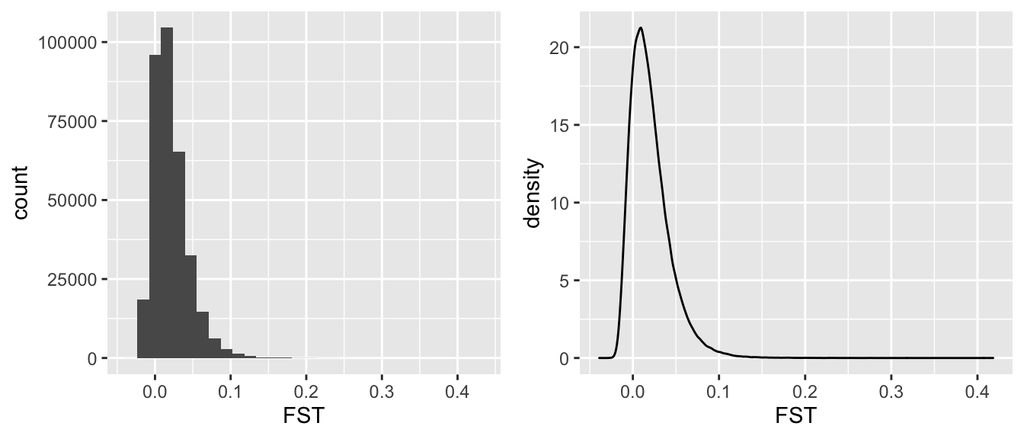

```r
h1 <- ggplot(pop_fst,aes(x = FST))+
  geom_histogram()
d1 <- ggplot(pop_fst,aes(x = FST))+
  geom_density()

plot_grid(h1,d1)
```

What do these distributions tell you about drift and selection in this system?

We can also read in our $F_{ST}$ values from our admixture populations, in order to compare marker-based $F_{ST}$ values.

```r
ad_fst <- read_delim("GreatTitsK4.fst", delim = "\t")
ad_fst
```

```
## # A tibble: 343,705 x 5
##      CHR SNP            POS NMISS       FST
##    <dbl> <chr>        <dbl> <dbl>     <dbl>
##  1     1 AX-100678681   511   212  0.0179
##  2     1 AX-100747228  5379   213 -0.000616
##  3     1 AX-100836047 21413   213  0.00803
##  4     1 AX-100918667 23383   213 -0.0110
##  5     1 AX-100974310 26112   213 -0.00596
##  6     1 AX-100811471 28471   213 -0.0110
##  7     1 AX-100414284 35125   212 -0.00616
##  8     1 AX-100837466 46003   213  0.0228
##  9     1 AX-100786950 46904   211  0.0141
## 10     1 AX-100015822 58982   209  0.0756
## # … with 343,695 more rows
```

Think of a good way of plotting the two sets of $F_{ST}$ values against one another in a way that summarises the data.

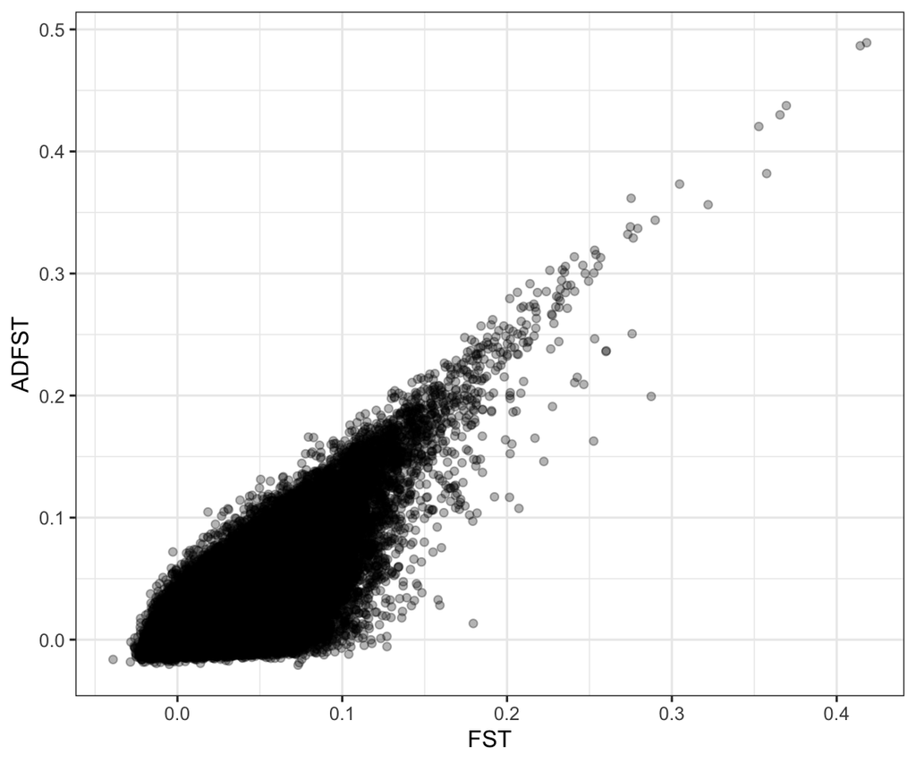

```r
pop_fst$ADFST <- ad_fst$FST

ggplot(pop_fst,aes(x = FST,y = ADFST))+
  geom_point(alpha = 0.3) +
  theme_bw()
```

Check the correlation coefficient between the two measures…

```r
cor(pop_fst$FST,pop_fst$ADFST)
```

```
## [1] NA
```

```r
#Need to remove NAs and try again
pop_fst <- filter(pop_fst,!is.na(FST) & !is.na(ADFST))
cor(pop_fst$FST,pop_fst$ADFST)
```

```
## [1] 0.753343
```

Let’s now take a look at the EigenGWAS data. First read in the eigenvector file and look at the data…

```r
ev <- read_delim("GreatTitsUnrel.eigenvec", delim = "\t", col_names = F)
ev
```

```
## # A tibble: 213 x 7
##    X1                      X2      X3      X4     X5     X6 X7
##    <chr>                <dbl>   <dbl>   <dbl>  <dbl>  <dbl> <lgl>
##  1 Loch_Lomond_Scotland   238 -0.0277 -0.0991 0.0143 0.0171 NA
##  2 Loch_Lomond_Scotland   240 -0.0437 -0.247  0.0572 0.0555 NA
##  3 Loch_Lomond_Scotland   241 -0.0401 -0.238  0.0514 0.0488 NA
##  4 Loch_Lomond_Scotland   244 -0.0411 -0.228  0.0446 0.0454 NA
##  5 Loch_Lomond_Scotland   246 -0.0403 -0.230  0.0525 0.0493 NA
##  6 Loch_Lomond_Scotland   248 -0.0294 -0.158  0.0286 0.0217 NA
##  7 Loch_Lomond_Scotland   251 -0.0383 -0.184  0.0372 0.0349 NA
##  8 Loch_Lomond_Scotland   254 -0.0329 -0.160  0.0303 0.0298 NA
##  9 Loch_Lomond_Scotland   257 -0.0349 -0.174  0.0356 0.0295 NA
## 10 Loch_Lomond_Scotland   259 -0.0406 -0.250  0.0448 0.0484 NA
## # … with 203 more rows
```

This conveniently has the population and individual IDs as the first two columns. Define come column names.

```r
colnames(ev) <- c("Population","Individual",paste0("PC",c(1:4)))
```

Now make some PCA plots

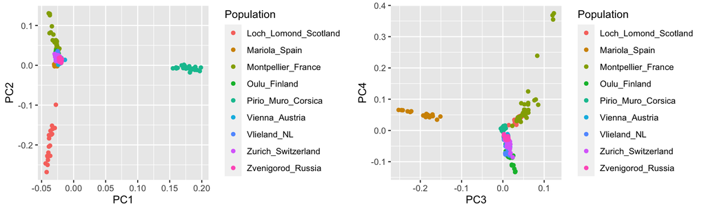

```r
F1 <- ggplot(ev,aes(x = PC1,y = PC2,col = Population))+
  geom_point()

F2 <- ggplot(ev,aes(x = PC3,y = PC4,col = Population))+
  geom_point()

plot_grid(F1,F2)
```

EigenGWAS runs a GWAS on each of these four Eigenvectors. What do these four analyses tell us about selection?

Let’s load in the analysis from the first Eigenvector and take a look at the results.

```r
eg1 <- read_delim("GreatTitsUnrel.1.egwas", delim = "\t")
eg1
```

```
## # A tibble: 343,705 x 16
##    SNP     CHR    BP RefAllele AltAllele  freq     Beta     SE    Chi      P
##    <chr> <dbl> <dbl> <chr>     <chr>     <dbl>    <dbl>  <dbl>  <dbl>  <dbl>
##  1 AX-1…     1   511 C         T         0.179 -1.66e-2 0.0081 4.18   0.0409
##  2 AX-1…     1  5379 A         G         0.268 -1.10e-2 0.0073 2.23   0.135
##  3 AX-1…     1 21413 C         G         0.368  6.00e-4 0.0069 0.007  0.933
##  4 AX-1…     1 23383 G         A         0.387 -3.30e-3 0.0066 0.247  0.619
##  5 AX-1…     1 26112 A         G         0.399  1.10e-3 0.0067 0.0253 0.874
##  6 AX-1…     1 28471 T         G         0.441 -1.80e-3 0.0067 0.075  0.784
##  7 AX-1…     1 35125 C         G         0.234 -2.50e-3 0.008  0.0966 0.756
##  8 AX-1…     1 46003 T         C         0.481 -1.65e-2 0.0067 5.98   0.0144
##  9 AX-1…     1 46904 G         T         0.434 -1.55e-2 0.0067 5.38   0.0204
## 10 AX-1…     1 58982 A         G         0.237  2.00e-4 0.0057 0.0017 0.967
## # … with 343,695 more rows, and 6 more variables: PGC <dbl>, n1 <dbl>,
## #   freq1 <dbl>, n2 <dbl>, freq2 <dbl>, Fst <dbl>
```

Let’s see how well out EigenGWAS p value and $F_{ST}$ are correlated

```r
cor(eg1$PGC,eg1$Fst)
```

```
## [1] NA
```

```r
#Need to remove NAs and try again
eg1 <- eg1[complete.cases(eg1),]
cor(eg1$PGC,eg1$Fst)
```

```
## [1] -0.7453333
```

They are strongly negatively correlated. Is that what we expect?

Finally, we will use ggplot to produce a basic Manhattan plot of the corrected EigenGWAS p-values. Try produce the plot below.

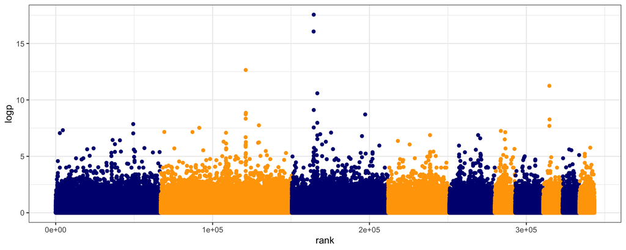

```r
eg1 %>%
  mutate(logp = -log10(PGC),
         rank = c(1:nrow(eg1))) %>%
  ggplot(aes(x = rank,y = logp,col = factor(CHR)))+
  geom_point()+
  theme_bw()+
  theme(legend.position = "none")+
  scale_color_manual(values = rep(c("navy","orange"),20))
```

## Over to you

Make a publication-quality figure summarising the selection analyses you have done. You can adapt figures we have already made or (better still) make completely new ones. For example, you may want to consider:

- Manhattan plots for the other eigenvectors
- Manhattan plots for FST
- qqplots from the eigenGWAS analysis
- Going to the great tit reference genome (link below) and finding whether SNPs under divergent selection are in genes https://www.ncbi.nlm.nih.gov/genome/gdv/browser/?context=genome&acc=GCF_001522545.2
- Combining your selection and population structure plots into a single figure.

Be creative!